# Optimizers

[figure not shown]

## Vanishing gradients on sigmoids

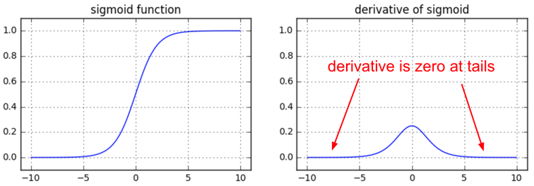

### if you’re using sigmoids or tanh non-linearities in your network and you understand backpropagation you should always be nervous about making sure that the initialization doesn’t cause them to be fully saturated.

## Dying ReLUs

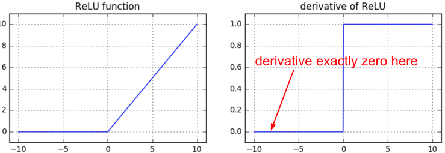

### If you understand backpropagation and your network has ReLUs, you’re always nervous about dead ReLUs. These are neurons that never turn on for any example in your entire training set, and will remain permanently dead.

## what about "Exploding gradients"?

# AlexNet (2012)

The one that started it all (Though some may say that Yann LeCun’s paper in 1998 was the real pioneering publication). This paper, titled “ImageNet Classification with Deep Convolutional Networks”, has been cited a total of 6,184 times and is widely regarded as one of the most influential publications in the field. Alex Krizhevsky, Ilya Sutskever, and Geoffrey Hinton created a “large, deep convolutional neural network” that was used to win the 2012 ILSVRC (ImageNet Large-Scale Visual Recognition Challenge). For those that aren’t familiar, this competition can be thought of as the annual Olympics of computer vision, where teams from across the world compete to see who has the best computer vision model for tasks such as classification, localization, detection, and more. **2012 marked the first year where a CNN was used to achieve a top 5 test error rate of 15.4% (Top 5 error is the rate at which, given an image, the model does not output the correct label with its top 5 predictions). The next best entry achieved an error of 26.2%**, which was an astounding improvement that pretty much shocked the computer vision community. Safe to say, CNNs became household names in the competition from then on out.

[figure not shown]

In the paper, the group discussed the architecture of the network (which was called AlexNet). They used a relatively simple layout, compared to modern architectures. The network was made up of 5 conv layers, max-pooling layers, dropout layers, and 3 fully connected layers. The network they designed was used for classification with 1000 possible categories.

## Main Points

- Trained the network on ImageNet data, which contained over 15 million annotated images from a total of over 22,000 categories.
- Used ReLU for the nonlinearity functions (Found to decrease training time as ReLUs are several times faster than the conventional tanh function).
- Used data augmentation techniques that consisted of image translations, horizontal reflections, and patch extractions.
- Implemented dropout layers in order to combat the problem of overfitting to the training data.
- Trained the model using batch stochastic gradient descent, with specific values for momentum and weight decay.
- Trained on two GTX 580 GPUs for five to six days.

## Why It’s Important

The neural network developed by Krizhevsky, Sutskever, and Hinton in 2012 was the coming out party for CNNs in the computer vision community. This was the first time a model performed so well on a historically difficult ImageNet dataset. Utilizing techniques that are still used today, such as data augmentation and dropout, this paper really illustrated the benefits of CNNs and backed them up with record breaking performance in the competition.

# ZF Net (2013)

With AlexNet stealing the show in 2012, there was a large increase in the number of CNN models submitted to ILSVRC 2013. The winner of the competition that year was a network built by Matthew Zeiler and Rob Fergus from NYU. Named ZF Net, **this model achieved an 11.2% error rate**. This architecture was more of a fine tuning to the previous AlexNet structure, but still developed some very keys ideas about improving performance. Another reason this was such a great paper is that the authors spent a good amount of time explaining a lot of **the intuition behind ConvNets and showing how to visualize the filters and weights correctly.**

In this paper titled “Visualizing and Understanding Convolutional Neural Networks”, Zeiler and Fergus begin by discussing the idea that this renewed interest in CNNs is due to the accessibility of large training sets and increased computational power with the usage of GPUs. They also talk about the limited knowledge that researchers had on inner mechanisms of these models, saying that without this insight, the “development of better models is reduced to trial and error”. While we do currently have a better understanding than 6 years ago, this still remains an issue for a lot of researchers! The main contributions of this paper are details of a slightly modified AlexNet model and a very interesting way of visualizing feature maps.

[figure not shown]

## Main Points

- Very similar architecture to AlexNet, except for a few minor modifications.
- AlexNet trained on 15 million images, while ZF Net trained on only 1.3 million images.
- Instead of using 11x11 sized filters in the first layer (which is what AlexNet implemented), ZF Net used filters of size 7x7 and a decreased stride value. The reasoning behind this modification is that a smaller filter size in the first conv layer helps retain a lot of original pixel information in the input volume. A filtering of size 11x11 proved to be skipping a lot of relevant information, especially as this is the first conv layer.
- As the network grows, we also see a rise in the number of filters used.
- Used ReLUs for their activation functions, cross-entropy loss for the error function, and trained using batch stochastic gradient descent.
- Trained on a GTX 580 GPU for twelve days.
- Developed a visualization technique named Deconvolutional Network, which helps to examine different feature activations and their relation to the input space. Called “deconvnet” because it maps features to pixels (the opposite of what a convolutional layer does).

# VGG Net (2014)

Simplicity and depth. That’s what a model created in 2014 (weren’t the winners of ILSVRC 2014) best utilized with its **7.3% error rate**. Karen Simonyan and Andrew Zisserman of the University of Oxford created a 19 layer CNN that strictly used 3x3 filters with stride and pad of 1, along with 2x2 maxpooling layers with stride 2. Simple enough right?

[figure not shown]

## Main Points

- The use of only 3x3 sized filters is quite different from AlexNet’s 11x11 filters in the first layer and ZF Net’s 7x7 filters. The authors’ reasoning is that the combination of two 3x3 conv layers has an effective receptive field of 5x5. This in turn simulates a larger filter while keeping the benefits of smaller filter sizes. One of the benefits is a decrease in the number of parameters. Also, with two conv layers, we’re able to use two ReLU layers instead of one.
- 3 conv layers back to back have an effective receptive field of 7x7.
- As the spatial size of the input volumes at each layer decrease (result of the conv and pool layers), the depth of the volumes increase due to the increased number of filters as you go down the network.
- Interesting to notice that the number of filters doubles after each maxpool layer. This reinforces the idea of shrinking spatial dimensions, but growing depth.
- Worked well on both image classification and localization tasks. The authors used a form of localization as regression (see page 10 of the paper for all details).
- Built model with the Caffe toolbox.
- Used scale jittering as one data augmentation technique during training.
- Used ReLU layers after each conv layer and trained with batch gradient descent.
- Trained on 4 Nvidia Titan Black GPUs for two to three weeks.

## Why It’s Important

VGG Net is one of the most influential papers in my mind because it reinforced the notion that convolutional neural networks have to have a deep network of layers in order for this hierarchical representation of visual data to work. Keep it deep. Keep it simple.

[figure not shown]

# ResNet

original paper: https://arxiv.org/pdf/1512.03385.pdf

[figure not shown]

## Motivation

Network depth is of crucial importance in neural network architectures, but deeper networks are more difficult to train. The residual learning framework eases the training of these networks, and enables them to be substantially deeper — leading to improved performance in both visual and non-visual tasks. These residual networks are much deeper than their ‘plain’ counterparts, yet they require a similar number of parameters (weights).

## The (degradation) problem:

With network depth increasing, accuracy gets saturated (which might be unsurprising) and then degrades rapidly. Unexpectedly, such degradation is not caused by overfitting, and adding more layers to a suitably deep model leads to higher training error.

## The core insight:

Let us consider a shallower architecture and its deeper counterpart that adds more layers onto it. There exists a solution to the deeper model by construction: the layers are copied from the learned shallower model, and the added layers are identity mapping. The existence of this constructed solution indicates that a deeper model should produce no higher training error than its shallower counterpart.

## The proposed solution:

[figure not shown]

Instead of hoping each stack of layers directly fits a desired underlying mapping, we explicitly let these layers fit a residual mapping. The original mapping is recast into F(x)+x. We hypothesize that it is easier to optimize the residual mapping than to optimize the original, unreferenced mapping. To the extreme, if an identity mapping were optimal, it would be easier to push the residual to zero than to fit an identity mapping by a stack of nonlinear layers. We have reformulated the fundamental building block (figure above) of our network under the assumption that the optimal function a block is trying to model is closer to an identity mapping than to a zero mapping, and that it should be easier to find the perturbations with reference to an identity mapping than to a zero mapping. This simplifies the optimization of our network at almost no cost. Subsequent blocks in our network are thus responsible for fine-tuning the output of a previous block, instead of having to generate the desired output from scratch.

[figure not shown]

https://towardsdatascience.com/review-densenet-image-classification-b6631a8ef803

## DenseNet — Dense Convolutional Network (Image Classification)

[figure not shown]

In Standard ConvNet, input image goes through multiple convolution and obtain high-level features.

[figure not shown]

In ResNet, identity mapping is proposed to promote the gradient propagation. Element-wise addition is used. It can be viewed as algorithms with a state passed from one ResNet module to another one.

[figure not shown]

In DenseNet, each layer obtains additional inputs from all preceding layers and passes on its own feature-maps to all subsequent layers. Concatenation is used. Each layer is receiving a “collective knowledge” from all preceding layers.

[figure not shown]

Since each layer receives feature maps from all preceding layers, network can be thinner and compact, i.e. number of channels can be fewer. The growth rate k is the additional number of channels for each layer. So, it have higher computational efficiency and memory efficiency. The following figure shows the concept of concatenation during forward propagation:

[figure not shown]

### Basic DenseNet Composition Layer

[figure not shown]

For each composition layer, Pre-Activation Batch Norm (BN) and ReLU, then 3×3 Conv are done with output feature maps of k channels, say for example, to transform x0, x1, x2, x3 to x4. This is the idea from Pre-Activation ResNet.

[figure not shown]

To reduce the model complexity and size, BN-ReLU-1×1 Conv is done before BN-ReLU-3×3 Conv.

[figure not shown]

1×1 Conv followed by 2×2 average pooling are used as the transition layers between two contiguous dense blocks. Feature map sizes are the same within the dense block so that they can be concatenated together easily. At the end of the last dense block, a global average pooling is performed and then a softmax classifier is attached.

#### Advantages of DenseNet

- Strong Gradient Flow

[figure not shown]

  The error signal can be easily propagated to earlier layers more directly. This is a kind of implicit deep supervision as earlier layers can get direct supervision from the final classification layer. Parameter & Computational Efficiency

[figure not shown]

  For each layer, number of parameters in ResNet is directly proportional to C×C while Number of parameters in DenseNet is directly proportional to l×k×k. Since k<<C, DenseNet has much smaller size than ResNet.
- More Diversified Features

[figure not shown]

  Since each layer in DenseNet receive all preceding layers as input, more diversified features and tends to have richer patterns.
- Maintains Low Complexity Features

[figure not shown]

  In Standard ConvNet, classifier uses most complex features.

[figure not shown]

  In DenseNet, classifier uses features of all complexity levels. It tends to give more smooth decision boundaries. It also explains why DenseNet performs well when training data is insufficient.

# Global Average Pooling

http://ethereon.github.io/netscope/#/gist/db945b393d40bfa26006

tensor with dimensions h×w×d is reduced in size to have dimensions 1×1×d. GAP layers reduce each h×w feature map to a single number by simply taking the average of all hw values.

[figure not shown]

- reduce overfitting (less need for dropout)
- less constraint on input size

https://alexisbcook.github.io/2017/global-average-pooling-layers-for-object-localization/ In pytorch use:

`import torch.nn.functional as F`

`x = F.adaptive_avg_pool2d(x, (1, 1))`

```python
%matplotlib inline
```

# Transfer Learning tutorial

In this tutorial, you will learn how to train your network using transfer learning. You can read more about the transfer learning at `cs231n notes http://cs231n.github.io/transfer-learning/

Quoting this notes,

```
In practice, very few people train an entire Convolutional Network
from scratch (with random initialization), because it is relatively
rare to have a dataset of sufficient size. Instead, it is common to
pretrain a ConvNet on a very large dataset (e.g. ImageNet, which
contains 1.2 million images with 1000 categories), and then use the
ConvNet either as an initialization or a fixed feature extractor for
the task of interest.
```

These two major transfer learning scenarios looks as follows:

- **Finetuning the convnet**: Instead of random initializaion, we initialize the network with a pretrained network, like the one that is trained on imagenet 1000 dataset. Rest of the training looks as usual.
- **ConvNet as fixed feature extractor**: Here, we will freeze the weights for all of the network except that of the final fully connected layer. This last fully connected layer is replaced with a new one with random weights and only this layer is trained.

```python
# License: BSD
# Author: Sasank Chilamkurthy

from __future__ import print_function, division

import torch
import torch.nn as nn
import torch.optim as optim
from torch.optim import lr_scheduler
import numpy as np
import torchvision
from torchvision import datasets, models, transforms
import matplotlib.pyplot as plt
import time
import os
import copy

plt.ion()   # interactive mode
```

## Load Data

We will use torchvision and torch.utils.data packages for loading the data.

The problem we're going to solve today is to train a model to classify **ants** and **bees**. We have about 120 training images each for ants and bees. There are 75 validation images for each class. Usually, this is a very small dataset to generalize upon, if trained from scratch. Since we are using transfer learning, we should be able to generalize reasonably well.

This dataset is a very small subset of imagenet.

```python
!wget https://download.pytorch.org/tutorial/hymenoptera_data.zip #Download the data from
!unzip hymenoptera_data.zip #extract it to the current directory.
```

[output not shown]

[output cut: 362 more lines]

[output not shown]

```python
# Data augmentation and normalization for training
# Just normalization for validation
data_transforms = {
    'train': transforms.Compose([
        transforms.RandomResizedCrop(224),
        transforms.RandomHorizontalFlip(),
        transforms.ToTensor(),
        transforms.Normalize([0.485, 0.456, 0.406], [0.229, 0.224, 0.225])
    ]),
    'val': transforms.Compose([
        transforms.Resize(256),
        transforms.CenterCrop(224),
        transforms.ToTensor(),
        transforms.Normalize([0.485, 0.456, 0.406], [0.229, 0.224, 0.225])
    ]),
}

data_dir = 'hymenoptera_data'
image_datasets = {x: datasets.ImageFolder(os.path.join(data_dir, x),
                                          data_transforms[x])
                  for x in ['train', 'val']}
dataloaders = {x: torch.utils.data.DataLoader(image_datasets[x], batch_size=32,
                                             shuffle=True, num_workers=4)
              for x in ['train', 'val']}
dataset_sizes = {x: len(image_datasets[x]) for x in ['train', 'val']}
class_names = image_datasets['train'].classes

avDev = torch.device("cuda:1")
```

# Visualize a few images

Let's visualize a few training images so as to understand the data augmentations.

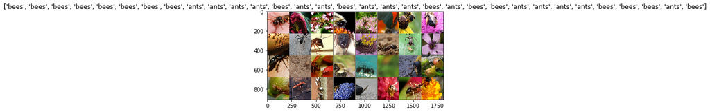

```python
def imshow(inp, title=None):
    """Imshow for Tensor."""
    inp = inp.numpy().transpose((1, 2, 0))
    mean = np.array([0.485, 0.456, 0.406])
    std = np.array([0.229, 0.224, 0.225])
    inp = std * inp + mean
    inp = np.clip(inp, 0, 1)
    plt.imshow(inp)
    if title is not None:
        plt.title(title)
    plt.pause(0.001)  # pause a bit so that plots are updated


# Get a batch of training data
inputs, classes = next(iter(dataloaders['train']))

# Make a grid from batch
out = torchvision.utils.make_grid(inputs)

imshow(out, title=[class_names[x] for x in classes])
```

## Training the model

Now, let's write a general function to train a model. Here, we will illustrate:

- Scheduling the learning rate
- Saving the best model

In the following, parameter `scheduler` is an LR scheduler object from `torch.optim.lr_scheduler`.

```python
def train_model(model, criterion, optimizer, scheduler, num_epochs=25):
    since = time.time()

    best_model_wts = copy.deepcopy(model.state_dict())
    best_acc = 0.0

    for epoch in range(num_epochs):
        print('Epoch {}/{}'.format(epoch, num_epochs - 1))
        print('-' * 10)

        # Each epoch has a training and validation phase
        for phase in ['train', 'val']:
            if phase == 'train':
                scheduler.step()
                model.train()  # Set model to training mode
            else:
                model.eval()   # Set model to evaluate mode

            running_loss = 0.0
            running_corrects = 0

            # Iterate over data.
            for inputs, labels in dataloaders[phase]:
                inputs = inputs.to(avDev)
                labels = labels.to(avDev)

                # zero the parameter gradients
                optimizer.zero_grad()

                # forward
                # track history if only in train
                with torch.set_grad_enabled(phase == 'train'):
                    outputs = model(inputs)
                    _, preds = torch.max(outputs, 1)
                    loss = criterion(outputs, labels)

                    # backward + optimize only if in training phase
                    if phase == 'train':
                        loss.backward()
                        optimizer.step()

                # statistics
                running_loss += loss.item() * inputs.size(0)
                running_corrects += torch.sum(preds == labels.data)

            epoch_loss = running_loss / dataset_sizes[phase]
            epoch_acc = running_corrects.double() / dataset_sizes[phase]

            print('{} Loss: {:.4f} Acc: {:.4f}'.format(
                phase, epoch_loss, epoch_acc))

            # deep copy the model
            if phase == 'val' and epoch_acc > best_acc:
                best_acc = epoch_acc
                best_model_wts = copy.deepcopy(model.state_dict())

        print()

    time_elapsed = time.time() - since
    print('Training complete in {:.0f}m {:.0f}s'.format(
        time_elapsed // 60, time_elapsed % 60))
    print('Best val Acc: {:4f}'.format(best_acc))

    # load best model weights
    model.load_state_dict(best_model_wts)
    return model
```

# Visualizing the model predictions

Generic function to display predictions for a few images

```python
def visualize_model(model, num_images=6):
    images_so_far = 0
    fig = plt.figure()

    for i, data in enumerate(dataloaders['val']):
        inputs, labels = data

        inputs, labels = inputs.to(avDev), labels.to(avDev)

        outputs = model(inputs)
        _, preds = torch.max(outputs.data, 1)

        for j in range(inputs.size()[0]):
            images_so_far += 1
            ax = plt.subplot(num_images//2, 2, images_so_far)
            ax.axis('off')
            ax.set_title('predicted: {}'.format(class_names[preds[j]]))
            imshow(inputs.cpu()[j])

            if images_so_far == num_images:
                return
```

## Finetuning the convnet

Load a pretrained model and reset final fully connected layer.

```python
model_ft = models.resnet18(pretrained=True) # check: https://github.com/pytorch/vision/blob/master/torchvision/models/resnet.py
num_ftrs = model_ft.fc.in_features
model_ft.fc = nn.Linear(num_ftrs, 2)

model_ft = model_ft.to(avDev)

criterion = nn.CrossEntropyLoss()

# Observe that all parameters are being optimized
optimizer_ft = optim.SGD(model_ft.parameters(), lr=0.001, momentum=0.9)

# Decay LR by a factor of 0.1 every 7 epochs
exp_lr_scheduler = lr_scheduler.StepLR(optimizer_ft, step_size=7, gamma=0.1)
```

# Train and evaluate

It should take around 15-25 min on CPU. On GPU though, it takes less than a minute.

```python
model_ft = train_model(model_ft, criterion, optimizer_ft, exp_lr_scheduler,
                       num_epochs=25)
```

```
----------
train Loss: 0.6550 Acc: 0.6025
val Loss: 0.4989 Acc: 0.7778

----------
train Loss: 0.4254 Acc: 0.8607
val Loss: 0.3079 Acc: 0.9085

----------
train Loss: 0.3059 Acc: 0.8852
val Loss: 0.2167 Acc: 0.9477

----------
train Loss: 0.2115 Acc: 0.9303
val Loss: 0.1918 Acc: 0.9477

----------
train Loss: 0.1670 Acc: 0.9549
val Loss: 0.1798 Acc: 0.9542

----------
train Loss: 0.1564 Acc: 0.9426
val Loss: 0.1697 Acc: 0.9608

----------
train Loss: 0.1440 Acc: 0.9672
val Loss: 0.1603 Acc: 0.9542

----------
train Loss: 0.1748 Acc: 0.9467
val Loss: 0.1626 Acc: 0.9608

----------
train Loss: 0.1730 Acc: 0.9262
val Loss: 0.1619 Acc: 0.9542

----------
train Loss: 0.1481 Acc: 0.9426
val Loss: 0.1618 Acc: 0.9608

```

[output cut: 47 more lines]

```

----------
train Loss: 0.1483 Acc: 0.9631
val Loss: 0.1607 Acc: 0.9608

----------
train Loss: 0.1401 Acc: 0.9631
val Loss: 0.1619 Acc: 0.9608

----------
train Loss: 0.1444 Acc: 0.9590
val Loss: 0.1616 Acc: 0.9608

Training complete in 0m 58s
Best val Acc: 0.960784
```

```python
visualize_model(model_ft)
```

[output not shown]

## ConvNet as fixed feature extractor

Here, we need to freeze all the network except the final layer. We need to set `requires_grad == False` to freeze the parameters so that the gradients are not computed in `backward()`.

You can read more about this in the documentation `here http://pytorch.org/docs/notes/autograd.html#excluding-subgraphs-from-backward

```python
model_conv = torchvision.models.resnet18(pretrained=True)
for param in model_conv.parameters():
    param.requires_grad = False

# Parameters of newly constructed modules have requires_grad=True by default
num_ftrs = model_conv.fc.in_features
model_conv.fc = nn.Linear(num_ftrs, 2)

model_conv = model_conv.to(avDev)

criterion = nn.CrossEntropyLoss()

# Observe that only parameters of final layer are being optimized as
# opoosed to before.
optimizer_conv = optim.SGD(model_conv.fc.parameters(), lr=0.001, momentum=0.9)

# Decay LR by a factor of 0.1 every 7 epochs
exp_lr_scheduler = lr_scheduler.StepLR(optimizer_conv, step_size=7, gamma=0.1)
```

# Train and evaluate

On CPU this will take about half the time compared to previous scenario. This is expected as gradients don't need to be computed for most of the network. However, forward does need to be computed.

```python
model_conv = train_model(model_conv, criterion, optimizer_conv,
                         exp_lr_scheduler, num_epochs=25)
```

```
----------
train Loss: 0.6547 Acc: 0.6148
val Loss: 0.5540 Acc: 0.7124

----------
train Loss: 0.5659 Acc: 0.6926
val Loss: 0.3932 Acc: 0.8693

----------
train Loss: 0.4410 Acc: 0.8238
val Loss: 0.3024 Acc: 0.9281

----------
train Loss: 0.3089 Acc: 0.9098
val Loss: 0.2533 Acc: 0.9412

----------
train Loss: 0.2770 Acc: 0.9057
val Loss: 0.2251 Acc: 0.9412

----------
train Loss: 0.2457 Acc: 0.9303
val Loss: 0.2063 Acc: 0.9412

----------
train Loss: 0.2191 Acc: 0.9344
val Loss: 0.2016 Acc: 0.9477

----------
train Loss: 0.2155 Acc: 0.9303
val Loss: 0.1975 Acc: 0.9412

----------
train Loss: 0.2562 Acc: 0.8975
val Loss: 0.1923 Acc: 0.9412

----------
train Loss: 0.2268 Acc: 0.9262
val Loss: 0.1937 Acc: 0.9412

```

[output cut: 47 more lines]

```

----------
train Loss: 0.2066 Acc: 0.9303
val Loss: 0.1908 Acc: 0.9412

----------
train Loss: 0.2218 Acc: 0.9467
val Loss: 0.1908 Acc: 0.9412

----------
train Loss: 0.2257 Acc: 0.9180
val Loss: 0.1922 Acc: 0.9412

Training complete in 0m 53s
Best val Acc: 0.947712
```

```python
visualize_model(model_conv)

plt.ioff()
plt.show()
```

[output not shown]

# Assignment5

- Gather a dataset for humanoid robot you can use this:
  - https://www.youtube.com/watch?v=JdP0AG0FqwY
  - https://www.youtube.com/watch?v=6ldHWWHfeBc&t=5s
  - https://www.youtube.com/watch?v=WJKc56uUuF8
  - https://www.youtube.com/watch?v=RG205OwGdSg
  - https://www.youtube.com/watch?v=yVdB_0ry53o
  - https://www.youtube.com/watch?v=TWNvSHpMrSM
  - https://www.youtube.com/watch?v=UsmBD2_3FH8
  - https://www.youtube.com/watch?v=WGKo_6IkFBY
  - https://www.youtube.com/watch?v=G6xE7uWt6Fo&t=1s
  - https://www.youtube.com/watch?v=G9llFqAwI-8&t=17s
  - https://www.youtube.com/watch?v=t8Ni5cB9FCc&t=21s
  - https://www.youtube.com/watch?v=CLkcznptenE
  - https://www.youtube.com/watch?v=-FQOZTsEA1Y
  - https://www.youtube.com/watch?v=hkZAMO0y0Hs
  - https://www.youtube.com/watch?v=9saVpA3wIbU
  - https://www.youtube.com/watch?v=RC7ZNXclWWY
- Finetune DenseNet for your custom dataset of humanoid robot classification (Binary classification Robot/NoRobot)
- Use LR Scheduler of your choice!
- Extra point: include Mixup data augmentation for your model

[figure not shown]

## Refrences:

### CS231n Standford

### https://towardsdatascience.com/review-densenet-image-classification-b6631a8ef803

### https://adeshpande3.github.io/The-9-Deep-Learning-Papers-You-Need-To-Know-About.html

### http://ethereon.github.io/netscope/#/gist/db945b393d40bfa26006

### https://medium.com/@karpathy/yes-you-should-understand-backprop-e2f06eab496b